# 问题二第一问：当前实现对照与独立验证实施方案

> 用途：供脑电研究者审核当前实现与验证流程，并作为后续代码修改的执行依据。本文区分“现有代码已经实现的内容”和“建议新增的验证步骤”，不把方案草稿中的设想写成既有结果。

## 1. 当前目标与需要回答的问题

本节的首要目标是建立一个低维正向计算模型：以视觉刺激及其呈现时序为输入，以 F3、Fz、F4 的相对电位波形为输出，并明确描述刺激如何经过早期视觉中继、皮层群体动力学、等效源代理和简化容积传导映射形成头皮观测。模型应能逐模块计算、检查并与实测 ERP 波形进行适当对照。

本节首先回答：

1. 刺激特征如何转成 ON/OFF 与 TCR、IN、TRN 的时变输入和状态？
2. 早期视觉场、空间构型、三角模板偏好三组 E/I 群体如何由这些特征驱动并相互连接？
3. 群体活动如何形成五个语义明确的等效源代理，再通过固定简化头模型映射为 F3、Fz、F4？
4. 该正向链的数值实现是否正确，训练数据拟合得到的曲线能否在留出数据上解释实测条件 ERP 与左右差异波？

分类准确率不是本节正向模型是否建立成功的判定标准。单试次分类属于后续的次级验证，只用于描述左右响应的可分性；单凭分类结果不能证明 LGN—皮层机制正确。正向模型预测条件平均响应，模板分类器预测单试次标签，二者的对象和结论应分开报告。

## 2. 当前数据与项目路径

| 内容 | 项目位置 | 作用 |
| --- | --- | --- |
| 第一问清洗后数据 | `q1/output/8riemann_denoise/*_clean.mat` | 提供逐试次 EEG、相对时间、提示方向及数据质量字段 |
| 当前问题二模型 | `q2/revision_v3/` | 当前实际执行的正向模型代码 |
| 当前模型结果 | `q2/output/revision_v3/` | revision_v3 的拟合、响应、审计和评价结果 |
| 训练块模板解码基线 | `q2/15_record_specific_template_decoder.py` | 已实现按时间块留出、训练内选择特征和模板的经验基线 |
| 模板解码结果 | `q2/output/15_record_specific_template_decoder/` | 逐记录及逐试次的留出预测结果 |
| 探索性 54.2% 分析 | `q2/14_exploratory_local_window_decoder.py`、`q2/17_residual_template_match.py` | 用于探索候选电极/窗口；不能作为无泄漏独立测试成绩 |
| 论文书写指导 | `q2/documents/问题二第一小问_revision_v3_论文书写指导.md` | 需要在实现和验证冻结后同步修订 |

四个 `*_clean.mat` 是四份记录，不应直接等同为四名独立被试。跨记录结果应称为跨记录留出结果，并报告记录间差异。

## 3. 现有代码实际做了什么

以下描述以 `revision_v3` 当前代码为准。若论文稿、旧方案 PDF 或早期脚本使用了不同术语，应改论文使其符合实际实现；不应为了匹配草稿而把未实现模块写成已经实现。

### 3.1 数据输入与真实 ERP

`revision_v3/real_data.py` 读取第一问的 `*_clean.mat`，取出 `trial_data`、`relative_time`、`cue_type`、`DataLabel`、`SampleRate`、`drop` 等字段，选取 F3、Fz、F4，并将条件标签映射为左/右提示。Stage1 的方向分组使用 `cue_type=-1/+1`；动作相关字段用于诊断，不替代视觉提示标签。

该模块对每个试次按 `[-200, 0) ms` 做基线均值校正，输出通道顺序为 F3、Fz、F4 的试次矩阵、事件信息和质量诊断。输入已经经过第一问清洗与重采样；后续不得在没有明确依据时重复套用第一问滤波。

单试次基线校正按电极分别计算：
$$Y_{r,c,e}(t)=X_{r,c,e}(t)-\frac{1}{|\mathcal T_B|}
\sum_{u\in\mathcal T_B}X_{r,c,e}(u),\qquad
\mathcal T_B=[-200,0)\,\mathrm{ms}.$$
其中 r、c、e 分别索引记录、提示条件和电极；之后才对同一条件的试次求 ERP 均值。

**接口概括：**

```
输入：*_clean.mat
输出：每试次 EEG[F3,Fz,F4,time]、左右提示标签、时间轴、质量/事件诊断
```

### 3.2 刺激前端和 LGN 近似层

`revision_v3/frontend.py` 以标准化刺激矩阵为输入。Stage1 的刺激增量由提示图减去公共圆形基线得到，随后经过简化的 ON/OFF 中继及 TCR、IN、TRN 群体状态计算，再提取四个方向的 Gabor 响应，并生成固定几何的边缘、顶点和相对位置特征。

输出包括时间轴、ON/OFF/LGN 平均活动、方向响应、形状和方向码、左右构型响应及审计用特征图。该实现是确定性的 Gabor/几何构型编码，**不是 COSFIRE 实现**；LGN 部分也不是完整的离子通道或突触递质动力学模型。

**接口概括：**

```
输入：标准刺激/基线矩阵、阶段和刺激条件
输出：ON/OFF/LGN 活动、Gabor方向图、形状/位置构型特征
```

### 3.3 皮层群体动力学和头皮观测

`revision_v3/model.py` 将前端特征汇入三组兴奋/抑制功能群体：早期视觉场输入、空间构型输入、三角模板偏好。前两组的通道表示图像左/右视野，第三组表示左/右模板偏好。采用有界 Wilson–Cowan 风格动力学；目前只拟合共享的 `tau_s`、`g_i`、`tau_a` 和一个共享有符号增益，其余权重与延迟固定。

兴奋与抑制活动经突触滤波和显式语义路由形成五个相对源代理，再由 `head_model.py` 的固定近似映射形成 F3、Fz、F4 三通道模拟观测。源代理是模型中的相对量，不是经过个体头模型验证的真实解剖源；导联映射不应称为 MRI/BEM/FEM 个体化导联场。

**接口概括：**

```
输入：LGN/Gabor/空间构型/三角模板偏好特征
输出：各功能群体 E/I 活动、五个语义明确的源代理、F3/Fz/F4 模拟波形
```

### 3.3.1 从刺激图像到 ON/OFF 中继状态

对每个像素，标准化刺激增量定义为

$$I(x,y)=\frac{I_{\mathrm{image}}(x,y)-I_{\mathrm{baseline}}(x,y)}{255}.$$

当前静态 Stage1 cue-only 实现先在 128×128 网格上面积平均，再计算中心—周围差分：

$$S(x,y,t)=g(t)\left[(G_{\sigma_c}*I)(x,y)-(G_{\sigma_s}*I)(x,y)\right],\qquad
g(t)=\begin{cases}1,&0\leq t<200\text{ ms},\\0,&\text{otherwise.}\end{cases}$$

当前拟合/预测实际采用 128×128 网格，中心与周围标准差为 1.5 和 4.0 像素，对应原始 256 网格上的 3 和 8 像素。64×64 只用于分辨率审计与示例可视化；该网格的核能量二阶矩误差未通过审计，故未用于当前拟合。适应状态 A 初始为零，并按 1 ms 显式 Euler 步长更新。ON/OFF 瞬态驱动为

$$T=S-A,\qquad D_{\mathrm{ON}}=0.8[T]_+ +0.2[S]_+,\qquad
D_{\mathrm{OFF}}=0.8[-T]_+ +0.2[-S]_+,$$

其中 [z]₊=max(z,0)，适应时间常数 τₐ 当前默认 80 ms，候选拟合范围为 40–160 ms。Stage1 的 cue 在 200 ms 消失后，S 回到零而 A 按时间常数衰减，因此会产生 ON offset 瞬态；这不是额外手工添加的刺激。

对每个极性通道 k∈{ON,OFF}，TCR、IN、TRN 状态均从零开始，状态范围限制在 [0,1]。先定义归一化截断 logistic 函数

$$\phi_{\beta,\theta}(z)=\operatorname{clip}\!\left(
\frac{\operatorname{sigmoid}(\beta(z-\theta))-\operatorname{sigmoid}(-\beta\theta)}
{1-\operatorname{sigmoid}(-\beta\theta)},0,1\right),\qquad \phi(0)=0.$$

各群体目标状态和连续时间的一阶松弛方程为

$$\begin{aligned}
R_k^*&=\phi_{4,0.5}(2.2D_k-0.9N_k-0.8Q_k),\\
N_k^*&=\phi_{4,0.5}(1.2D_k+0.7R_k),\\
Q_k^*&=\phi_{4,0.5}(0.9R_k),\\
\tau_R\dot R_k&=-R_k+R_k^*,\quad
\tau_N\dot N_k=-N_k+N_k^*,\quad
\tau_Q\dot Q_k=-Q_k+Q_k^*,
\end{aligned}$$

其中 R、N、Q 分别表示 TCR、IN、TRN；固定时间常数为 18、12、25 ms。连接关系是：ON/OFF 驱动直接进入 TCR 与 IN；TCR 活动兴奋 IN 和 TRN；IN 与 TRN 对 TCR 产生抑制反馈。代码在 ON 与 OFF 两个极性通道上各自并行运行这组简化动力学。传给 Gabor 前端的有符号中继图为 R_ON−R_OFF，ON/OFF 群体平均和空间图也单独保留供检查。

### 3.3.2 Gabor 与几何构型特征如何形成三组群体输入

当前 128×128 网格上的 Gabor 标准差 σ=2 像素、波长 λ=5 像素、纵横比 γ=0.5，分别对应原始图像的 4、10 像素及 γ=0.5。对四个载波法向角 θ∈{0°,45°,90°,135°}，以偶/奇正交核滤波有符号中继图 R=R_ON−R_OFF，得到相位不敏感能量

$$V_\theta=\sqrt{(K_{\theta,e}*R)^2+(K_{\theta,o}*R)^2},\qquad
B=\frac{1}{2}\sqrt{\sum_\theta V_\theta^2}.$$

偶、奇核均减去离散均值后联合做 L2 归一化。特征每 4 ms 计算一次，再线性插值到 1 ms 时间轴。构型模板使用经过高斯平滑的方向图，平滑标准差在 128 网格上为 1 像素；在模板支持点处以双线性插值取样，并在相邻两个 Gabor 载波法向方向之间线性插值得到

$$r_m(x,y,t)=w_m^-\widetilde V_{\theta_m^-}((x,y)+\boldsymbol\delta_m,t)
+w_m^+\widetilde V_{\theta_m^+}((x,y)+\boldsymbol\delta_m,t),\qquad w_m^-+w_m^+=1.$$

固定三角模板由标准刺激掩膜的凸包确定顶点；在每条边上取三个支持点，在每个顶点相邻两边各取一个支持点。左右模板图采用对数域几何平均：

$$H_s(x,y,t)=\max\!\left[\exp\!\left(\frac{1}{6}
\sum_{m\in\mathcal E_s\cup\mathcal C_s}\log(r_m(x,y,t)+\epsilon)\right)-\epsilon,0\right],$$

其中 s∈{L,R}，𝓔ₛ 为三个边支持组的平均响应，𝓒ₛ 为三个顶点支持组的平均响应，ε=10⁻⁸。形状共同图为 H=H_L+H_R；模板中心 3×3 区域的平均响应记作 ρ_L、ρ_R，方向对手输入为 d_L=[ρ_L−ρ_R]₊、d_R=[ρ_R−ρ_L]₊。

当前代码将这些图/向量映射为三组、每组左右两个通道的外部驱动：

$$\begin{aligned}
p_{1,c}(t)&=\frac{\operatorname{mean}_{(x,y)\in\Omega_c} B(x,y,t)}{\sqrt2},\\
p_{2,c}(t)&=\frac{\operatorname{mean}_{(x,y)\in\Omega_c} H(x,y,t)}{\sqrt2},\\
p_{3,L}(t)&=d_L(t),\qquad p_{3,R}(t)=d_R(t),\\
D_{p,c}(t)&=p_{p,c}(t)/s_{p,c}.
\end{aligned}$$

这里 p=1、2、3 分别表示早期对比、形状共同、模板方向对手功能群体，c∈{L,R} 表示输入图像的左右视野半区，Ω₍c₎ 为对应的 8×8 网格区域；除第三组直接使用左右对手模板外，前两组通过 8×8 图的左右半区均值投影。除以 sₚ,c 是固定输入尺度校准，不是 EEG 拟合：在标准左右镜像提示上，对 0–200 ms 及两条件等权计算每通道 RMS。当前校准值为：早期组左右均约 7.2424×10⁻⁴，形状组左右均约 5.7140×10⁻⁴，方向对手组左右均为 2.32749×10⁻²。数值来自 output/revision_v3/drive_scales.csv。

### 3.3.3 三组 Wilson–Cowan 风格 E/I 群体及连接

三个功能群体各含左右两个通道；每个通道有一个兴奋活动 Eₚ,c 和一个抑制活动 Iₚ,c，初始值均为零。驱动延迟后记为 D̃₁,c(t)=D₁,c(t−8 ms)，D̃₂,c(t)=D₂,c(t−33 ms)，D̃₃,c(t)=D₃,c(t−33 ms)。外部输入电流代理为

$$\begin{aligned}
U^E_{p,c}&=1.4E_{p,c}-g_i(1.1)I_{p,c}+2.2\widetilde D_{p,c}
+\mathbf1_{p>1}(0.9)E_{1,c}(t-33),\\
U^I_{p,c}&=1.0E_{p,c}-0.8I_{p,c}+1.2\widetilde D_{p,c}
+\mathbf1_{p>1}(0.45)I_{1,c}(t-33).
\end{aligned}$$

兴奋和抑制群体分别更新为

$$\tau^E_p\dot E_{p,c}=-E_{p,c}+(1-E_{p,c})\phi_{5,0.35}(U^E_{p,c}),\qquad
\tau^I_p\dot I_{p,c}=-I_{p,c}+(1-I_{p,c})\phi_{5,0.35}(U^I_{p,c}).$$
早期组 τᴱ=18 ms、τᴵ=10 ms；构型组和模板偏好组 τᴱ=τₛ、τᴵ=0.55τₛ。代码用显式 Euler 法、1 ms 步长积分。连接结构是每个通道内的 E/I 局部反馈；群体 2、3 还接收早期组同一视觉半区输入的延迟前馈 E/I 活动。当前实现没有左右通道间的横向连接，也没有单独实现解剖学 V1、IT、PFC 网络。因此三组应解释为低维功能群体，而不是已辨识的三个脑区。修正后，前两组的 L/R 明确表示图像左/右视野半区；它们进入源代理时按对侧关系路由：左视野→右半球源，右视野→左半球源。第三组 L/R 表示左/右三角模板偏好，只用于构造有符号偏好差，不表示视野半区或半球位置。

### 3.3.4 从 E/I 群体到五个语义明确的源代理

每个功能群体的 E、I 活动分别经过突触响应核滤波，再相减形成群体净活动：

$$u_{p,c}(t)=(h_{10}*E_{p,c})(t)-(h_{20}*I_{p,c})(t),\qquad
h_\tau(t)=\frac{t e^{-t/\tau}}{\tau^2}\,\mathbf1_{t\ge0}.$$

离散核按单位面积归一化，采用因果卷积并在模拟起点前补零。源映射明确区分视野位置、形状偏好和源半球：

$$\mathbf q(t)=\begin{bmatrix}
u_{\mathrm{early},\mathrm{RVF}}(t)\\
u_{\mathrm{early},\mathrm{LVF}}(t)\\
u_{\mathrm{config},\mathrm{RVF}}(t)\\
u_{\mathrm{config},\mathrm{LVF}}(t)\\
u_{\mathrm{pref},\mathrm{left}}(t)-u_{\mathrm{pref},\mathrm{right}}(t)
\end{bmatrix}.$$

前两列分别是“右视野输入→左半球早期视觉源”和“左视野输入→右半球早期视觉源”；第 3、4 列对构型空间图采用同一对侧路由。第 5 列是左右三角模板偏好群体的有符号差，映射为单一双侧中线形状对手源；它不再拆成左右半球源。故源代理顺序为 `early_LH_from_RVF`、`early_RH_from_LVF`、`config_LH_from_RVF`、`config_RH_from_LVF`、`bilateral_shape_preference_opponent_midline`。这些是群体净活动构成的相对源代理，幅值无 A·m 的电流偶极单位，不代表经影像定位的解剖源。

### 3.3.5 五个源代理到 F3/Fz/F4 的简化头模型映射

当前导联矩阵不是任意调出的拟合权重。电极 F3/Fz/F4 与双侧乳突参考点投影到头部外表面半径 90 mm；五个功能源使用独立的头内坐标，不投影到头表面。源坐标采用规范、非个体化的近似位置，源方向暂定为从头中心向外的径向。对电极 e、源 j：

$$L_{ej}=\frac{\mathbf n_j\cdot(\mathbf r_e-\mathbf r_j)}
{4\pi\sigma\lVert\mathbf r_e-\mathbf r_j\rVert^3},\qquad
G_{ej}=L_{ej}-\frac{L_{M_1j}+L_{M_2j}}{2},\qquad
\mathbf V(t)=\mathbf G\mathbf q(t).$$
其中 σ=0.33 S/m，nⱼ 为指定的径向偶极方向；坐标在代码中以毫米给出后转换为米。源坐标顺序及头中心径向距离为：早期视觉左/右半球源 (−10,−58,45)/(10,−58,45) mm，半径均约 74.1 mm；构型左/右半球源 (−36,−25,50)/(36,−25,50) mm，半径均约 66.5 mm；双侧模板偏好中线源 (0,−34,56) mm，半径约 65.5 mm。相对 90 mm 外表面，其深度约为 15.9、23.5、24.5 mm。电极和参考的表面坐标及全部数值见 `head_model.geometry_manifest()`。源点均严格位于头内，传感器和参考点位于外表面；因此修正后的几何关系不再把源和电极放在同一半径上。

这只是“表面传感器 + 内部点偶极”的均匀无限导体近似，不是有限球体头模型的解析解，也不是 MRI/BEM/FEM 个体化导联场。源坐标和径向方向是为可复现计算设定的规范假设，不是 MRI、源定位或独立解剖测量得到的脑区坐标。修正后的 `G` 为 `3×5`，实际系数保存在重新运行生成的 `output/revision_v3/leadfield.csv`；当前旧输出仍属于修正前版本，不能当作新几何的结果。模型中的源电流仍为无量纲活动代理，故 `Gq` 不构成物理校准的 V 或 μV；拟合共享有符号增益也不校准源偶极矩。

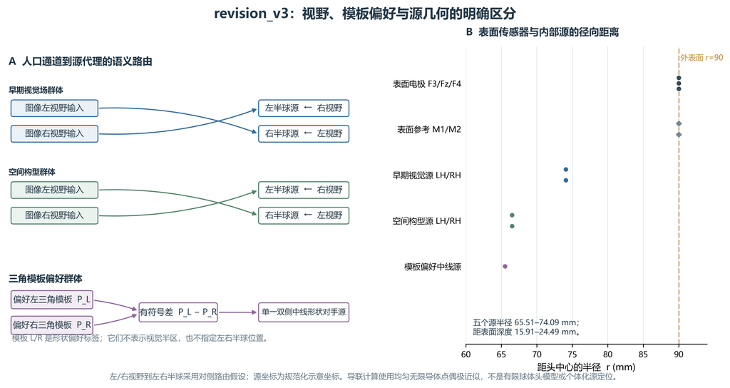

视野与模板偏好路由、内源与表面电极的几何关系

**图：修正后的源语义和几何审计示意。** 左侧区分视野左右、模板偏好与源半球：早期视觉及空间构型的视野通道按对侧关系投向半球源；左右模板偏好只形成一个双侧中线对手源。右侧比较径向距离：电极和参考位于 90 mm 外表面，模型源位于半径 65.5–74.1 mm 的头内区域。源坐标是规范化假设，导联仍采用均匀无限导体近似。

尽管该点偶极公式本身的量纲为 V/(A·m)，qₚ,c 是无物理单位的归一化活动差，因此未缩放的 Gq 不是物理校准的伏特或微伏。拟合时的共享增益 α 可把模型波形数值缩放到实测 EEG 的幅值范围以便波形比较，但这并未校准源偶极矩或证明绝对电位具有生理量纲；应把它称为经验尺度对齐后的模拟波形，而不能据此宣称获得了物理绝对电位。训练拟合只允许使用一个共享有符号增益，不对每个电极另行调权，避免把电极映射自由度吸收进源模型。

### 3.3.6 固定参数、拟合参数及其来源

| 参数类别 | 当前取值/定义 | 来源与论文解释 |
| --- | --- | --- |
| 时间网格与刺激时序 | 0–800 ms，1 ms；Stage1 cue 为 0–200 ms | revision_v3/config.py 的实验建模约定；应与事件记录核对，不是 EEG 拟合结果 |
| 空间滤波尺度 | 原 256 网格 DoG σ=3/8 px、Gabor σ=4 px/λ=10 px、模板平滑 σ=2 px；当前 128 网格对应 1.5/4、2/5、1 px | config.py 固定定义；当前 128 网格由 spatial_resolution_audit.json 预先选定；64 网格核矩二阶矩误差未通过，故不用于当前拟合 |
| LGN 动力学 | τTCR=18 ms、τIN=12 ms、τTRN=25 ms；适应 τₐ 默认 80 ms | 固定的简化模型初值/设计值；τₐ 在拟合时仅从 40–160 ms 的 20 ms 网格中选择 |
| 皮层群体固定连接 | wEE=1.4、wEI=1.1、wIE=1.0、wII=0.8；gP=2.2、gQ=1.2；前馈 E/I=0.9/0.45 | config.py 中的候选模型设定，当前项目未给出针对这些具体数值的实测估计或文献标定；论文须标成固定假设/尺度参数 |
| 皮层时间与延迟 | 早期 τE/τI=18/10 ms、延迟 8 ms；后两组延迟 33 ms、τE=τₛ、τI=0.55τₛ | config.py 中的固定结构设定；除 τₛ 外未从 EEG 分别估计 |
| 训练拟合参数 | τₛ：形状/对手组兴奋时间常数；gᵢ：E 方程中抑制反馈的倍率；τₐ：视觉适应时间常数；α：共享有符号输出尺度。范围分别为 τₛ∈[20,100] ms、gᵢ∈[0.5,1.5]、τₐ∈[40,160] ms | 仅由训练条件 ERP 拟合；α 对固定动力学模型按加权最小二乘解析求得，不能解释为生理增益 |
| 输入尺度 | 0–200 ms 镜像左右标准 cue 的等权通道 RMS | 由固定标准刺激校准；不使用 EEG 标签或留出 EEG 估计 |
| 源—电极映射 | σ=0.33 S/m；电极/参考在 90 mm 外表面；五个源在半径约 65.5–74.1 mm 的头内位置；径向点偶极、双乳突平均参考 | head_model.py 的几何/传导假设；不是有限球体解；源坐标不是 MRI 定位或 EEG 源成像结果，映射不由 EEG 拟合 |

目前留一记录拟合的 τₛ 四折均达到 100 ms 上界，且优化器未收敛；例如 VisualCogA_Task-1 留出折的 τₛ=100 ms、gᵢ≈0.672、τₐ=80 ms、α≈−12.04。故拟合参数只能视为当前候选模型的数值解，不能当作稳定或生理真实参数。对固定权重、滤波尺度和坐标，如无外部文献依据，应明确报告为建模假设，而不要事后为其补造生理来源。

### 3.4 观测算子与模型拟合

`revision_v3/observation.py` 将模型输出放入 EEG 时间轴，施加与第一问相同类型的 0.2–24 Hz、四阶零相位 Butterworth 滤波，重采样到 128 Hz，并做 `[-200, 0) ms` 基线校正。

将事件窗内的模拟传感器曲线 V(t) 放入完整 epoch，当前实现对其余时段补零。观测变换可概括为

$$Y_{\mathrm{model}}=\mathcal B_{[-200,0)}\,\mathcal R_{128}\,
\mathcal F^{\mathrm{filtfilt}}_{0.2-24\,\mathrm{Hz},4}\,
\mathcal Z_{[-1,3]\,\mathrm{s}}\{\mathbf V(t)\},$$

其中 Z 表示嵌入完整 epoch 并对未模拟时段补零，F 是四阶双向 Butterworth 带通，R 是重采样到 128 Hz，B 是逐电极减去基线区间均值。由于零相位滤波会借用事件前后的波形，零填充的 cue-only 模型与真实连续试次的上下文可能不同；在正向 ERP 误差可解释之前，必须先核对或重建一致的完整刺激上下文。

frontend.py 中已有动态场景接口；是否能无歧义重建每条真实试次的完整刺激场景，仍需检查目标位置和事件记录。

`revision_v3/fit.py` 在 Stage1 左右条件平均 ERP 上拟合共享动力学参数；`fit_leave_one_record` 用留一记录方式评估跨记录拟合。现有运行记录显示各外层拟合中 `tau_s` 触及 100 ms 上界且优化器未收敛。因此当前参数解应视为边界受限的候选拟合，不能据此声称已得到稳定生理参数。

对固定参数 θ=(τₛ,gᵢ,τₐ)，拟合器只允许一个跨左右条件、跨电极共享的有符号尺度 α。其解析加权最小二乘解和目标函数为

$$\alpha^*(\theta)=\frac{\sum_j w_j\langle \widehat Y_j(\theta),Y_j\rangle}
{\sum_j w_j\lVert\widehat Y_j(\theta)\rVert_F^2},\qquad
\mathcal L(\theta)=\sum_jw_j\operatorname{mean}\!\left[
\left(Y_j-\alpha^*(\theta)\widehat Y_j(\theta)\right)^2\right],$$

其中 j 遍历训练记录及左右 cue 条件，记录与条件按相同权重进入损失；Y 与预测曲线都经过观测算子后再比较。留一记录的既有拟合不是时间块留出预测，新建时间块验证时 θ、α 及任何归一化量必须仅由该折训练块估计。α 允许正负号是因为当前源代理的符号并非解剖偶极朝向的实测定义。

当前头模型以双侧乳突平均作为参考；第一问清洗数据的实际参考方案尚须从采集/预处理记录确认。若两者不一致，不能仅靠基线均值校正消除参考差异，应先转换到共同参考或将映射解释限制为示意性相对观测。该参考核对是实测 ERP 波形对照的前置条件。

**接口概括：**

```
输入：模型模拟曲线、训练记录 ERP
输出：滤波/重采样/基线校正后的模拟曲线、拟合参数和损失
```

### 3.5 已有单试次分类结果（次级分析）

本小节记录现有分类结果，供后续次级可分性分析使用；分类准确率不是本节正向模型成立与否的标准，也不替代留出条件 ERP 波形预测。

`revision_v3/evaluate.py` 用预设的六维共同/侧化 ERP 特征和收缩 LDA 做留一记录分类；现有结果约为 balanced accuracy `0.453`、AUC `0.421`。这是当前跨记录分类基线，不是正向模型机制成立的证明。

`15_record_specific_template_decoder.py` 已按每份记录的时间顺序划分五个块。每折只用训练块选择电极/时间窗并建立左右 ERP 模板，再对留出块逐试次预测。现有完整波形模板结果为 `148/297=49.8%`，合并平衡准确率约 `0.500`、四记录宏平均平衡准确率约 `0.509`；局部窗口结果为 `140/297=47.1%`。它是当前可作为经验解码基线的无测试信息参与选择结果，仍需核对结果对应的数据版本和输入文件哈希后再正式引用。

此前报告的 `54.2% (161/297)` 来自全试次探索窗口的选择，再用于留出预测；测试试次的信息参与了电极/窗口选择。它只能作为探索性结果，不能称为独立留出准确率，也不应和训练块选择的结果并列为同等证据。

### 3.6 模块输入输出图与现有结果图

下图把当前正向模型的输入、模块接口和输出，与建议的时间块独立验证流程放在一起。上半部分是当前代码的正向数据流；下半部分是训练数据如何形成拟合/模板、测试块如何只用于最终评价。虚线表示把模型预测送到留出测试块评分。

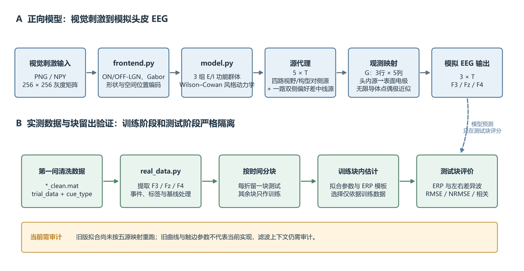

问题二第一问模块输入输出与验证流程

**图：问题二第一问模块输入输出与验证流程。** 上排中，刺激矩阵经过视觉前端和皮层功能群体模型，形成五个源代理（两个对侧视觉场源、两个对侧构型源、一个双侧形状对手中线源），经简化电极映射和观测处理得到 F3/Fz/F4 模拟波形；下排从第一问清洗数据形成训练/测试块，训练块负责估计，测试块负责评价。底部黄色框标出当前 v3 的两个主要审计点：cue-only 零填充的滤波上下文，以及部分参数触边、未收敛。

以下用当前 `revision_v3` 的真实文件和函数输出给每个模块举例。数组维度中的 `T=801` 指模型前端/动力学的 `0…800 ms`、1 ms 时间网格；真实 EEG 的采样网格为 128 Hz，所以每试次 0–800 ms 有 103 个实际采样点，最后一个点为 796.875 ms。

| 模块 | 输入例子 | 输出例子 | 图/文件证据 |
| --- | --- | --- | --- |
| 刺激读取 `frontend.load_stimulus` | `stage1_cue_left.npy` 与 `stage1_baseline_circle.npy`；各为 `256×256 uint8` | `image`、`baseline` 为 `256×256 float32`；`signed_contrast=(image-baseline)/255`，本例像素范围 `[-0.451, 0]` | 下方“前端模块 I/O 示例”左上 |
| 视觉前端/LGN `frontend.simulate_frontend` | 上述 `Stimulus` 与 `time_ms=0…800` | `lgn_on/off: 8×8×801`；`gabor: 4×8×8×801`；`B/H_L/H_R/shape/direction: 8×8×801`；选定时刻审计图为 `4×64×64` Gabor 图和 `64×64` 构型图 | 下方“前端模块 I/O 示例”其余面板 |
| EEG 数据读取 `real_data.load_dataset` | `VisualCogA_Task-1_clean.mat`：原始字段 `trial_data=54×10×512`、`SampleRate=128 Hz`、`cue_type=-1/+1` | 选出 F3/Fz/F4 后 `eeg=54×3×512`；本记录左/右提示分别 29/25 个试次。阶段 ERP 为每条件 `3×103`，并在每个试次内先减 `[-200,0) ms` 均值 | 下方“真实数据与皮层观测模块 I/O 示例”左上 |
| 皮层动力学 `model.simulate_forward` | 前端特征字典与参数；图中用默认 `tau_s=40 ms, g_i=1, tau_a=80 ms` | `excitatory/inhibitory=3×2×801`；三类群体 × 左右两个通道；输出曲线见第二张示例图右上 | 下方“真实数据与皮层观测模块 I/O 示例”右上 |
| 源代理 `model._source_proxy` | 皮层 E/I 状态 `3×2×801` | 突触核滤波后按视野/偏好语义路由，输出 `source_proxy=5×801`；不表示实测物理电流 | 下方“真实数据与皮层观测模块 I/O 示例”左下；路由证据见 `output/revision_v3_source_mapping_audit/population_to_source_routing.csv` |
| 头皮映射 `head_model.build_sensor_leadfield` | 五路语义明确的源代理；电极/参考在外表面，源在内部 | 导联矩阵 `G=3×5`，输出 `EEG=G·source=3×801`，三行依次为 F3/Fz/F4 | `output/revision_v3_source_mapping_audit/leadfield.csv`；完整坐标见同目录 `source_semantics_geometry_audit.json` |
| 观测处理 `observation.model_curve_to_q1_grid` | 模拟传感器曲线 `3×801`，嵌入 `[-1,3) s` 全历程 | 零填充后经 Q1 风格滤波、重采样和基线校正，输出 `3×512`、128 Hz；当前零填充上下文是否充分仍需按方案审计 | 第二张示例图右下；实现见 `revision_v3/observation.py` |
| 参数拟合 `fit.fit_leave_one_record` | 训练记录的左右 Stage1 平均 ERP 与模型预测 | 输出共享参数、增益、训练损失、优化状态和边界标志。现有示例中留出 `VisualCogA_Task-1` 时 `tau_s=100 ms`（上界）、`g_i≈0.672`、`tau_a=80 ms`，优化器未收敛。当前是留一 MAT 记录拟合，不是时间块留出正向预测 | `output/revision_v3/heldout_fit_summary.csv`、`heldout_fit_details.json`；拟合动态示例见下方图 |
| 分类评价 `evaluate.classification_leave_one_record` | 真实试次的固定六维时空特征与左右标签 | 现有留一 MAT 记录结果：balanced accuracy `0.453`、AUC `0.421`；这是实测特征分类基线，不等同于正向模型机制验证 | `output/revision_v3/fixed_feature_lda.csv` |
| 经验模板解码基线 `15_record_specific_template_decoder.py`（独立于 v3 正向链） | 第一问清洗试次、cue 标签；每折训练块 | 训练块内选特征/拟合左右模板，输出留出试次标签。现有全曲线模板结果 `148/297=49.8%`，平衡准确率约 `0.500`；作为基线，不表示已经稳健高于机会水平 | `output/15_record_specific_template_decoder/逐试次留出预测.csv`、`逐记录准确率.csv` |
| 运行编排 `run_v3.py` | 配置、标准刺激和四份清洗 MAT | 写出 manifest、事件/条件审计、拟合参数、模拟/实测曲线和指标 CSV/PNG | `output/revision_v3/manifest.json` 及同目录结果文件 |

**当前 revision_v3 的前端模块实图：**

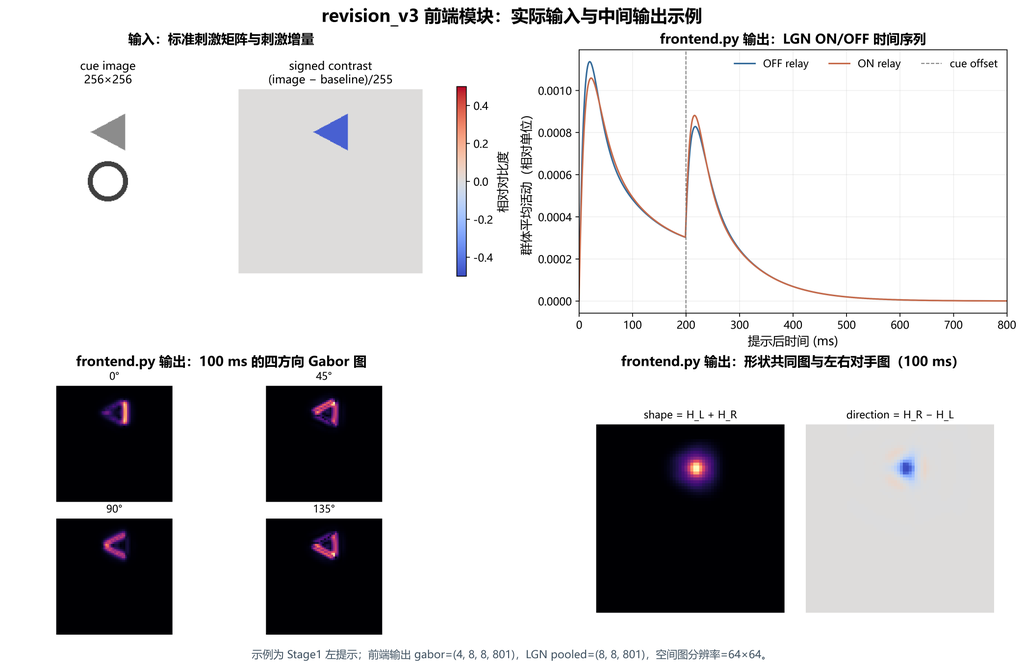

revision_v3 前端模块输入输出示例

图中直接使用 `load_stimulus` 与 `simulate_frontend` 的实际返回值，展示 cue 矩阵、刺激增量、LGN ON/OFF 时间序列、四个方向 Gabor 图以及形状共同/左右对手图。图示例固定为 Stage1 左提示、64×64 审计分辨率；图中的方向图来自 100 ms 审计帧。当前 revision_v3 拟合/预测运行使用分辨率审计选出的 128×128 网格。

**真实 EEG、皮层状态、源代理和观测输出实图：**

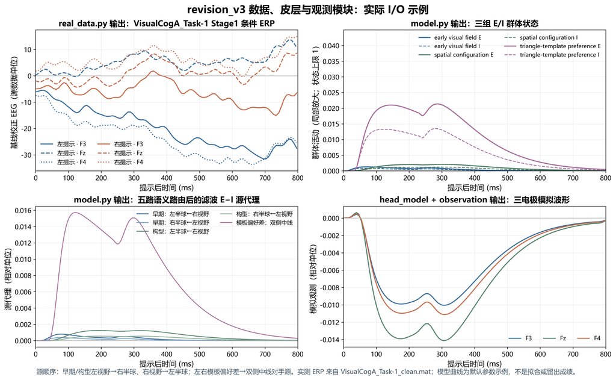

revision_v3 真实数据与皮层观测模块输入输出示例

左上为 `VisualCogA_Task-1_clean.mat` 经当前读取和逐试次基线处理后得到的左右提示 ERP；右上为三组 E/I 状态；左下已更新为当前五路源代理顺序；右下为经过当前简化导联和 Q1 风格观测处理的模拟三电极曲线。模型曲线使用默认参数，仅作模块 I/O 示例，**不是拟合结果或留出测试成绩**。现有拟合结果尚未按新源映射重跑，不能用旧拟合曲线解释当前模型。

本轮修正前生成的其他旧 `revision_v3` 曲线同样没有重新拟合；新几何和路由的直接证据以本节审计包为准。完整的训练/留出 ERP 结果必须在修正后重新运行 `run_v3.py` 与后续映射验证脚本生成，不能沿用旧输出解释新模型。

导联矩阵的五列顺序为“左半球源←右视野早期活动”、“右半球源←左视野早期活动”、“左半球构型源←右视野构型活动”、“右半球构型源←左视野构型活动”、“双侧形状偏好对手中线源”。新几何对应的系数如下（单位形式为 V/(A·m)，源代理本身没有 A·m 单位）：

| 电极 | early-LH←RVF | early-RH←LVF | config-LH←RVF | config-RH←LVF | bilateral-opponent-midline |  |
| --- | --- | --- | --- | --- | --- | --- |
| F3 | 0.661 | 0.961 | -2.688 | -4.365 | -0.330 |  |
| Fz | 1.101 | 1.101 | -4.299 | -4.299 | -0.489 |  |
| F4 | 0.961 | 0.661 | -4.365 | -2.688 | -0.330 |  |

该矩阵由 `revision_v3_source_mapping_audit/leadfield.csv` 复算，左右半球镜像源满足 F3/F4 对称交换；它来自固定的规范近似，不是由 MRI/个体头模型估计。虽然矩阵系数按代码公式有形式单位，乘数是无物理单位的模型源代理，因此最终曲线仍不能报告为真实 `μV`。

#### 本次语义与几何修正的可复核证据

| 审计项 | 修正后的实现 | 可复核证据 |
| --- | --- | --- |
| 视野位置与早期视觉半球 | 左视野输入进右半球源；右视野输入进左半球源；构型空间通道使用相同对侧路由 | `population_to_source_routing.csv` 中对应输入列各只有一个系数为 1，且落在对侧源行 |
| 形状偏好与源位置 | 左/右三角模板偏好按 `left preference − right preference` 形成一个双侧中线对手源，不将偏好名称解释为半球 | 路由表最后两列均进入第 5 行，系数分别 `+1/-1`；JSON 坐标中该源 `x=0` |
| 电极、参考与源的半径 | F3/Fz/F4 和双侧乳突参考半径为 90 mm；五个源半径为 65.5–74.1 mm，距外表面 15.9–24.5 mm | `source_semantics_geometry_audit.json` 的 `geometry_checks` |
| 导联矩阵维度和对称性 | 新矩阵是满行秩 `3×5`；左右半球镜像源的 F3/F4 系数按镜像交换 | 同一 JSON 中 `leadfield_shape`、`leadfield_rank`、`mirrored_hemisphere_leadfield_symmetry_F3_LH_equals_F4_RH`；系数见 CSV |
| 观测计算 | 当前模拟电位仍由 `EEG = G @ source_proxy` 得到，源数和 G 列数一致 | `test_source_semantics_geometry.py` 的端到端投影断言；`test_v3_contract.py` 的传感器方程断言 |

运行方式：`python src/C/q2/revision_v3/audit_source_mapping_geometry.py`。修正后 revision_v3 回归测试为 **17 passed**。该验收证明代码执行了明示的对侧路由、模板偏好差映射和内外层坐标关系；它不证明这些规范源坐标是个体真实解剖定位，也不把均匀无限导体近似变成有限球体头模型。第一问真实数据的参考方式仍需从采集/清洗元数据确认。

当前模型刺激输入示例为 Stage1 左、右提示图。二者是标准化灰度矩阵的可视化；模型实际读取的是相应矩阵数据，而不是这张排版示意图。

左提示输入

右提示输入

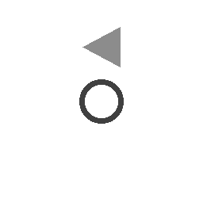

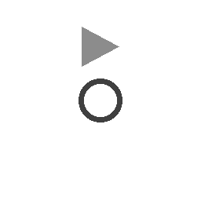

下面两张是现有 `revision_v3` 输出样例，用来展示当前代码确实产生了群体级联曲线和模拟/实测 ERP 对照。它们不是本方案所要求的时间块留出正向预测结果；其中灰色带表示现有结果中的变化/不确定范围，具体统计口径以对应输出脚本和 CSV 为准。

**现有模型级联输出示例：**

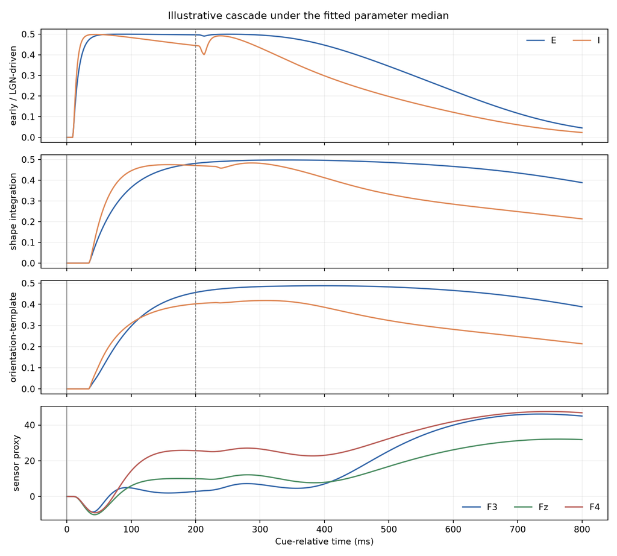

revision_v3 群体级联响应

**现有留出记录 ERP 对照示例：**

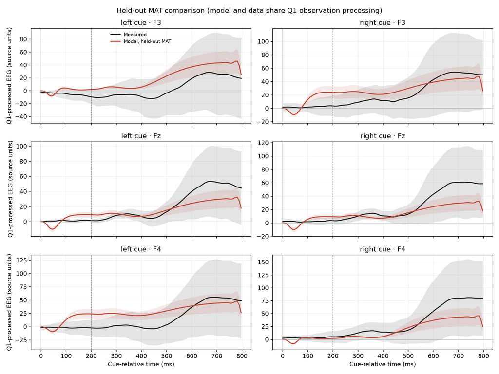

revision_v3 模拟与实测 ERP 对照

## 4. 论文与代码需要统一的内容

| 论文/草案中可能出现的表述 | 当前实际实现 | 处理原则 |
| --- | --- | --- |
| COSFIRE 形状检测 | 固定 Gabor 与几何模板构型编码 | 改写为实际实现；若要称 COSFIRE，需另行实现并验证 |
| 完整突触/离子通道 LGN | 简化 ON/OFF 与 TCR-IN-TRN 群体状态 | 明确为低维近似，不写成完整微观机制 |
| 明确 V1→IT→PFC 解剖网络 | 三组功能性 E/I 群体及固定延迟/权重 | 称为功能性层级代理，不声称已辨识脑区解剖参数 |
| 个体化三层球头模型 | 固定近似源到三电极映射 | 限定为示意性观测映射，不宣称个体化头模型 |
| 54.2% 独立预测效果 | 特征窗口曾用全部试次探索选择 | 降级为探索结果；独立验证以训练块选择结果为准 |
| 已得到稳定生理动力学参数 | 多折参数碰到边界且未收敛 | 报告边界/收敛诊断，不作生理参数结论 |

实现前应逐段检查论文公式和图表，建立“论文陈述—代码位置—输出证据”映射。凡没有代码和结果支持的内容，先改写或标注为计划，不纳入已完成方法。

## 5. 建议执行方案

### 阶段 A：冻结模型版本并核对输入数据

1. 备份并冻结现有 revision_v3、输出目录及论文稿，不覆盖旧结果。
2. 对四个清洗 MAT 记录文件名、大小、修改时间和哈希，核对字段、采样率、事件零点、提示标签、试次数及缺失/削顶信息。
3. 确认视觉提示 0 ms onset、200 ms offset、刺激基线和 EEG epoch 时间轴的对应关系；将无法由事件记录确认的上下文标记为待核实，不以假设填补。
4. 将旧分类结果和探索结果封存为次级历史材料，不在本阶段据其分数调整正向模型。

阶段输出：数据清单、输入哈希、事件/标签核查表、冻结的旧结果索引。

### 阶段 B：核对公式、模块连接和数值实现

先按本文件第 3.3.1–3.3.6 节逐式对照代码，形成“公式—函数—输入/输出—参数来源”清单。当前目标是确认正向链确实按所写关系运行，不以分类准确率作为验收条件。

至少执行以下数值检查：

1. 输入刺激左右镜像关系、公共基线和 0–200 ms cue 时序正确；ON/OFF 驱动符号符合暗刺激出现产生 OFF、暗刺激消失产生 ON 的编码约定。
2. LGN 的 TCR、IN、TRN 和皮层 E/I 状态均有限且位于 [0,1]；零输入、零初始状态时不应自发产生非零活动；所有数组时间轴和通道维度相符。
3. 前端输出维度为四方向 Gabor 图、8×8 空间图和左右构型/模板偏好向量；群体状态为 3×2×T，源代理为 5×T，导联矩阵为 3×5，传感器输出为 3×T。
4. 左右镜像输入经过固定空间编码后，应呈现相应的左右交换关系；固定导联矩阵应满足代码中的镜像对称关系。逐项计算 Gq 并确认输出与矩阵乘法一致。
5. 报告驱动尺度、E/I 状态范围、源代理幅值范围、导联矩阵秩和参数边界命中情况。不得将无物理单位的源代理/电位写成 μV。
6. 将代表性模块输出与本文件的输入—输出图核对；记录公式与代码不一致之处，并先修正论文表述或实现后再拟合。

这些是正向模型的数值正确性检查，不等同于神经机制已被实测数据验证。

### 阶段 C：修正正向模型的训练—测试边界和刺激上下文

新增一个独立的 blocked forward validation runner，输出到新目录，例如：

```
q2/output/revision_v3_blocked_forward/
```

不覆盖 `output/revision_v3/`。每份记录按同样五个时间块做外层留出。每折中，参数、尺度、模板或读出权重只能由训练块估计；留出块只用于最终评分。

拟合目标先限定为 Stage1 左、右条件平均 ERP 和左右差异波，不尝试拟合单试次随机波动。模型输入使用真实刺激事件定义；应核对并尽可能重建：

```
提示前公共圆形场景
提示出现：公共圆 + 方向提示
提示约 200 ms 后提示消失，回到公共圆
后续目标事件（若其影响滤波/评价窗，则按真实时序纳入）
```

必须使真实数据和模拟数据经过相同的滤波、重采样、参考/基线处理及时间截取，并对零相位滤波前后的边界效应做检查。若当前事件文件不足以确定完整场景，不得猜测或伪造目标标签；应将定量结论限定为上下文可确定的时段，并在报告中说明限制。

### 阶段 D：训练内拟合，测试块一次性评估

每个外层折按以下顺序执行：

1. 在训练块构造左右条件 ERP 均值与差异波。
2. 只用训练数据拟合现有共享参数化（`tau_s`、`g_i`、`tau_a`、共享增益）；保留预先固定的参数边界与优化器，不用测试折调参。
3. 训练内保存拟合状态、边界命中情况、收敛标志和损失。
4. 生成左右条件预测曲线，使用完整观测算子处理后，对测试块条件平均 ERP 评分。
5. 计算测试块左右差异波的误差与相关；测试块不得反馈到拟合、归一化、符号选择或窗口选择。

当前拟合器若不能接收折内训练数据，应最小幅度扩展 `fit.py` 的输入接口；不能沿用全数据拟合出的参数再声称测试块为独立模型预测。

### 阶段 E：预先固定的模型对照

只做足以回答空间编码贡献的三个对照，且每个模型都在相同训练/测试折上运行：

1. **经验 ERP 模板基线：** 使用训练块左右模板，作为简单预测对照。
2. **完整位置编码正向模型：** 使用当前 Gabor/构型位置特征。
3. **去位置编码对照：** 保持其他组件和参数规则一致，仅移除左右空间排列信息。

不在这一轮加入生成式似然比、空间神经场、参数恢复或大规模超参数搜索。这些既非题目完成的必要前提，也会扩大调参自由度。

### 阶段 F：指标与结果解释

正向模型比较条件平均曲线，不把它包装成单试次分类器。建议报告：

- 每个电极、每个条件的测试块 ERP RMSE/NRMSE；
- 测试块右减左差异波的 RMSE/NRMSE 与波形相关；
- 共同模式与左右差异模式的误差，必要时同时给绝对单位和归一化指标；
- 每折拟合参数、边界命中、优化器收敛状态；
- 逐记录与逐折结果，而非只给合并平均曲线。

分类基线单独报告准确率、平衡准确率、混淆矩阵及不确定性。四份记录数量有限，不将逐试次样本量误当作独立受试者数量；若给出显著性推断，应以记录/时间块为分析层级并谨慎解释。

不预设“必须达到某个准确率/相关系数”的人为门槛。结论根据训练块模板、完整模型、去位置模型在留出块上的相对结果给出：模型预测是否优于简单基线、位置编码是否提供增益、结果在哪些记录上不稳定，以及参数是否受边界限制。

### 阶段 G：最后进行次级单试次分类验证

正向模型的公式审计、数值检查、实测 ERP 波形对照和模型比较完成后，再汇总既有单试次分类结果。使用已经实现的按时间块留出 ERP 模板流程作为经验基线；保持分类器和规则不变，不用测试块重新挑选电极、时间窗、符号或阈值。报告逐记录准确率、平衡准确率、混淆矩阵和不确定性，并明确分类结果只回答“试次标签是否可分”，不作为正向模型建立成功的必要条件。此前使用全试次选窗得到的 54.2% 仍只能列为探索结果，不作为独立留出成绩。

## 6. 代码改动范围建议

| 文件 | 建议动作 | 理由 |
| --- | --- | --- |
| `revision_v3/config.py` | 冻结当前参数定义；必要时增加明确的场景事件时间配置 | 防止实验时间定义散落在多个脚本 |
| `revision_v3/real_data.py` | 核验输入哈希、标签、事件/时间轴；原则上不改清洗逻辑 | 第一问清洗结果为共同数据入口 |
| `revision_v3/frontend.py` | 优先复用动态场景接口；仅在完整事件上下文确实需要时小幅扩展 | 避免 cue-only 零填充与真实场景不一致 |
| `revision_v3/observation.py` | 明确对模拟信号施加与真实数据一致的滤波/重采样/基线流程，并增加上下文/边界处理 | 避免滤波算子输入上下文不一致 |
| `revision_v3/fit.py` | 接受当前外层折的训练数据；确保拟合、增益与尺度估计只见训练折 | 建立真正的折内正向预测 |
| `revision_v3/evaluate.py` | 增加 held-out 条件 ERP/差异波指标和位置消融对照 | 评价模型解释与泛化，而非只评价分类 |
| `revision_v3/blocked_forward_validation.py` | 新增单一编排脚本 | 固定折划分、运行模型对照、保存审计信息和结果 |
| `15_record_specific_template_decoder.py` | 先审计并复用；只有输入版本或泄漏检查失败才修 | 已经实现训练内窗口选择和训练内模板 |
| `14_exploratory_local_window_decoder.py`、`17_residual_template_match.py` | 保留探索用途并在输出/论文中注明非独立验证 | 避免把探索窗口选择结果误报为留出效果 |

每折建议保存简洁的机器可读 manifest：输入文件哈希、试次索引、训练/测试块、候选特征选择、训练模板来源、参数、优化状态、测试指标及代码版本。严禁测试标签参与特征或方向规则选择。

## 7. 执行顺序与交付物

```
1. 冻结 revision_v3 和旧结果，核对输入数据、事件语义及论文—代码映射
2. 对照模块方程，核查刺激输入、连接、初始条件、固定参数及源—电位计算
3. 完成数值审计，记录维度、状态范围、镜像关系、导联矩阵与边界诊断
4. 统一完整刺激上下文和观测算子，避免 cue-only 零填充与真实 ERP 上下文不一致
5. 训练块内拟合正向模型，在留出块预测条件平均 ERP 和左右差异波
6. 用相同划分比较经验 ERP 基线、完整模型和去位置编码模型
7. 将单试次分类作为次级分析，最后汇总局限与论文表述
```

预期新增/更新内容：

- `revision_v3/blocked_forward_validation.py`：折划分、训练拟合、留出预测与对照编排；
- 视上下文审计结果，对 `frontend.py`、`observation.py`、`fit.py`、`evaluate.py` 做最小必要接口修改；
- `output/revision_v3_blocked_forward/`：逐记录逐折的预测曲线、指标表、参数/收敛诊断和 manifest；
- 更新 `问题二第一小问_revision_v3_论文书写指导.md`：只纳入实际实现、可复现的独立验证结果。

## 8. 验收标准

本问的主要验收对象是低维正向模型的数值正确性和留出条件 ERP 波形预测；分类分数不设为门槛。只有同时满足以下条件，才能把结果称为训练—测试独立验证：

1. 每个测试块在该折中从未参与通道、窗口、参数、增益、尺度、方向符号或模型选择。
2. 左右 ERP 模板和所有可训练量均只来自训练块。
3. 训练和测试的真实/模拟曲线采用一致且记录清楚的事件时间、滤波、重采样、参考及基线定义。
4. 每个测试块只评分一次；看过测试结果后不回头调整同一轮模型。
5. 经验模板、完整位置模型、去位置模型使用相同外层折与相同评分指标。
6. 报告优化器未收敛、参数触边、记录间差异和刺激上下文不确定性，不将其隐藏或解释成生理发现。
7. 论文中每项机制主张都能对应到代码位置、输出文件和留出结果；未实现的 COSFIRE、完整 LGN 微观动力学或个体头模型不再作为既有成果陈述。

## 9. 给审核者的具体确认点

请脑电研究者优先判断以下方法问题，而非先要求增加模块：

1. 第一问 `*_clean.mat` 中 `trial_data` 的时间零点、`cue_type` 标签和 `[-200,0) ms` 基线定义是否与问题二使用方式一致？
2. 第一问滤波后的完整记录与当前模型 cue-only 零填充信号，是否会因零相位滤波上下文而产生不可比的事件响应？若会，应重建哪些刺激事件上下文？
3. 五个按时间顺序的块是否适合作为当前记录的外层留出；是否需要以连续试次时间块而非随机分折来控制漂移？
4. 用训练块均值拟合条件 ERP、再评估测试块条件 ERP，是否是当前正向机制模型最恰当的验证对象？
5. 对“完整位置编码模型 vs 去位置编码模型”的比较，当前三电极数据量是否足够支撑？应如何限制其解释范围？
6. 源映射已改为左视野→右半球源、右视野→左半球源；模板偏好差进入单一双侧中线源。剩余核对项是第一问真实数据采用的参考方式是否与当前双乳突平均参考假设一致；若元数据不能确认，头皮幅值解释须限定为相对模拟观测。

当前已经有视觉—LGN近似—皮层功能群体—头皮观测的候选正向链，也有训练块留出的经验 ERP 模板解码基线。但现有正向拟合并未完成严格的折内训练/测试预测，刺激上下文存在 cue-only 与真实连续试次不一致的风险，部分参数拟合触边且未收敛。此前 54.2% 结果存在全试次特征窗口选择带来的信息泄漏，不能作为独立泛化成绩。

因此，下一步的判别性工作是：统一论文与代码、核对数据和事件语义、在完整且可解释的观测流程下实施块留出的正向模型预测，并与训练内经验模板和去位置编码模型比较。完成这一步后，才能有依据判断问题主要来自数据/事件处理、模型结构、观测映射还是当前记录本身左右差异较弱。

## 11. 参考材料

- 方案草稿（用于核对其主张与当前实现的差异）：deepseek_latex_20260924_12fa90(1).pdf。草稿中描述的 COSFIRE、完整 LGN 微观动力学、Kuramoto 网络和三层球头模型等，不应自动视为 `revision_v3` 已实现内容。
- 当前论文说明材料：问题二第一小问_revision_v3_论文书写指导.md。